# Datasets in R / Packages in R / Bar plots / Boxplots / Timeplots

Sulalitha Bowala

## Datasets in R

R comes with several datasets built into its base installation, which are available for users to explore and use for various data analysis and statistical tasks. These datasets are typically used for practice, examples, and teaching purposes. Here are some of the commonly used datasets that come with R by default:

- 1. **Iris Dataset:** Perhaps one of the most famous datasets, it contains measurements of iris flowers from three different species: setosa, versicolor, and virginica. It’s often used for classification tasks.
- 2. **mtcars Dataset:** This dataset provides information about various car models, including attributes such as miles per gallon, horsepower, and more. It’s frequently used for regression analysis.
- 3. **ChickWeight Dataset:** This dataset contains information about the weights of chickens at different time points and under different diets. It’s commonly used for longitudinal data analysis.
- 4. **AirPassengers Dataset:** This dataset represents the number of international airline passengers over several years. It’s widely used for time series analysis.
- 5. **CO2 Dataset:** This dataset contains measurements of CO2 uptake by different plants. It’s used for experiments involving plants and environmental factors.
- 6. **USArrests Dataset:** This dataset provides crime statistics for U.S. states, including murder rates, assault rates, and more. It’s often used for crime analysis and visualization.
- 7. **swiss Dataset:** This dataset contains socioeconomic data for the regions of Switzerland. It’s used for regional and multivariate analysis.
8. **BOD Dataset:** This dataset contains measurements of dissolved oxygen in the water at different time points. It’s often used for simple time series analysis.
- 9. **faithful Dataset:** This dataset contains information about the eruption times and waiting times between eruptions of the Old Faithful geyser in Yellowstone National Park. It’s commonly used for analyzing waiting times.
- 10. **women Dataset:** This dataset provides data on the average heights and weights of women in a hypothetical population. It’s used for simple statistical demonstrations.

These datasets are valuable for learning and practicing data analysis techniques in R, and they cover a wide range of data types and structures, making them suitable for different types of analyses and exercises.

These datasets are readily available for use by loading them into your R session using the `data()` function.

```r
data(iris)
```

Observe that the above code creates a dataframe in the “Environment Window” with the name “iris”. We can access the dataset by typing the name “iris”. For an example:

```r
head(iris)
```

```
##   Sepal.Length Sepal.Width Petal.Length Petal.Width Species
## 1          5.1         3.5          1.4         0.2  setosa
## 2          4.9         3.0          1.4         0.2  setosa
## 3          4.7         3.2          1.3         0.2  setosa
## 4          4.6         3.1          1.5         0.2  setosa
## 5          5.0         3.6          1.4         0.2  setosa
## 6          5.4         3.9          1.7         0.4  setosa
```

```r
mean(iris$Sepal.Length)
```

```
## [1] 5.843333
```

## Packages in R

So far in our labs, we have been using various functions such as ‘mean()’, ‘hist()’, and ‘median()’, and datasets such as ‘iris’. All of these functions and datasets are readily available when you install R and RStudio. There are, however, more functions and datasets that can be installed. These come in what are called **packages**.

Installing and loading a new package in R is a two-step process:

- Step 1: You must install the package. This is done with the **install.packages()** function. **This only needs to be done once**.
- Step 2: You must load in the package. This is done with the **library()** function. **This needs to be done for every new session**. That means that if you close and re-open R, you will have to load the package with “library()” again. It also means that you need to put it somewhere in your code chunk before you use it when making an RMarkdown file.

R has dozens of packages, each of which are generally purposed for a particular type of analysis.

Example:

- **ggplot2** Package: This popular data visualization package provides several datasets that are commonly used to create visualizations. For instance, the diamonds dataset contains information about diamonds, including their carat weight, cut, color, clarity, and price.

```r
library(ggplot2)

data(diamonds)

head(diamonds)
```

```
## # A tibble: 6 × 10
##   carat cut       color clarity depth table price     x     y     z
##   <dbl> <ord>     <ord> <ord>   <dbl> <dbl> <int> <dbl> <dbl> <dbl>
## 1  0.23 Ideal     E     SI2      61.5    55   326  3.95  3.98  2.43
## 2  0.21 Premium   E     SI1      59.8    61   326  3.89  3.84  2.31
## 3  0.23 Good      E     VS1      56.9    65   327  4.05  4.07  2.31
## 4  0.29 Premium   I     VS2      62.4    58   334  4.2   4.23  2.63
## 5  0.31 Good      J     SI2      63.3    58   335  4.34  4.35  2.75
## 6  0.24 Very Good J     VVS2     62.8    57   336  3.94  3.96  2.48
```

```r
# More details about the diamond dataset can be found in R Help
# Run the following command in Console
# ?diamonds
```

## Tables and Bar Graphs

R can produce bar graphs, which are closely linked to histograms (though they are reserved for categorical, not quantitative, data).

To produce a bar graph, we first need a frequency table. To produce a frequency table of a categorical variable in R, we use the **table()** function.

Let’s consider the dataset “mtcars” available in the R package “datasets”. The data was extracted from the 1974 Motor Trend US magazine, and comprises fuel consumption and 10 aspects of automobile design and performance for 32 automobiles (1973–74 models).

```r
data(mtcars)

# More details about the mtcars dataset can be found in R Help. Run the following command in Console
# ?diamonds
```

Column 2 in “mtcars” is named “cyl” and it indicates the number of cylinders in each car. Let’s say we want to get a barplot for “cyl” to see how many cars are there with different numbers of cylinders.

- Step 1: We will use **table()** to create a frequency table of the “cyl”

```r
# Option 1
Num_Cyl <- mtcars$cyl
table(Num_Cyl)
```

```
## Num_Cyl
##  4  6  8
## 11  7 14
```

```r
# Option 2
table(mtcars$cyl)
```

```
##
##  4  6  8
## 11  7 14
```

- Step 2: Make this into a bar graph using the function “barplot()”

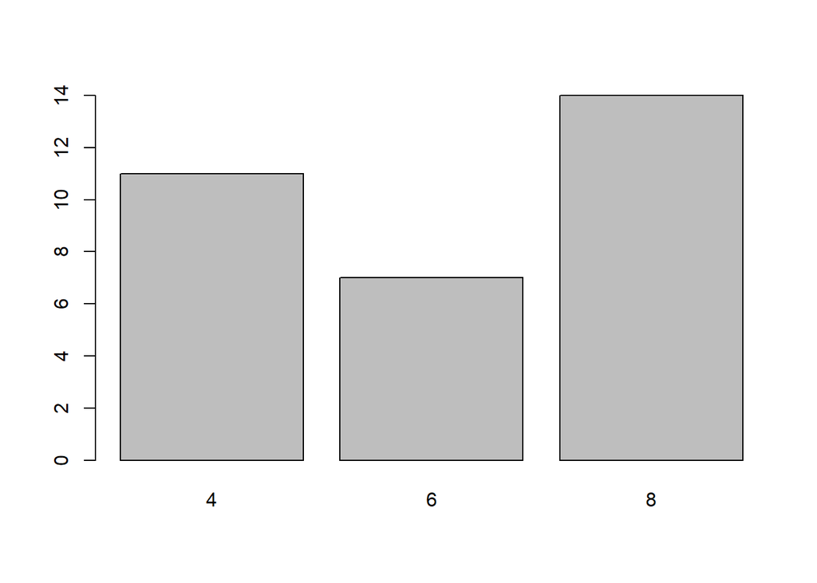

```r
barplot(table(mtcars$cyl))
```

We can use the “main”, “xlab”, “ylab”, and “col” arguments as in “hist()” function to make a prettier graph.

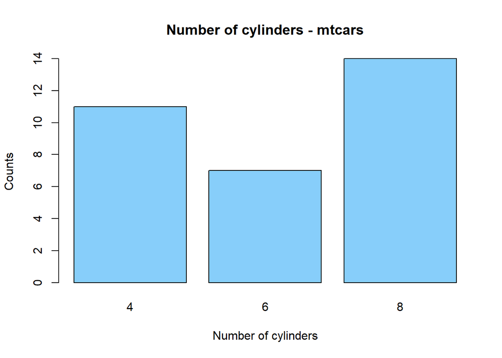

```r
barplot(table(mtcars$cyl), main = "Number of cylinders - mtcars",
        xlab = "Number of cylinders", ylab = "Counts", col = "lightskyblue")
```

Recall from Lab 2 we can also access particular rows, columns, or cells by attaching two square brackets next to our dataframe’s name and giving a locator. The same operator can be used to select specific rows of a dataframe based on a given condition.

For example, let’s say we want to observe data of all cars which have more than 4 cylinders. We can isolate the corresponding data by imposing a condition on column values.

```r
mtcars[mtcars$cyl > 4,]
```

```
##                      mpg cyl  disp  hp drat    wt  qsec vs am gear carb
## Mazda RX4           21.0   6 160.0 110 3.90 2.620 16.46  0  1    4    4
## Mazda RX4 Wag       21.0   6 160.0 110 3.90 2.875 17.02  0  1    4    4
## Hornet 4 Drive      21.4   6 258.0 110 3.08 3.215 19.44  1  0    3    1
## Hornet Sportabout   18.7   8 360.0 175 3.15 3.440 17.02  0  0    3    2
## Valiant             18.1   6 225.0 105 2.76 3.460 20.22  1  0    3    1
## Duster 360          14.3   8 360.0 245 3.21 3.570 15.84  0  0    3    4
## Merc 280            19.2   6 167.6 123 3.92 3.440 18.30  1  0    4    4
## Merc 280C           17.8   6 167.6 123 3.92 3.440 18.90  1  0    4    4
## Merc 450SE          16.4   8 275.8 180 3.07 4.070 17.40  0  0    3    3
## Merc 450SL          17.3   8 275.8 180 3.07 3.730 17.60  0  0    3    3
## Merc 450SLC         15.2   8 275.8 180 3.07 3.780 18.00  0  0    3    3
## Cadillac Fleetwood  10.4   8 472.0 205 2.93 5.250 17.98  0  0    3    4
## Lincoln Continental 10.4   8 460.0 215 3.00 5.424 17.82  0  0    3    4
## Chrysler Imperial   14.7   8 440.0 230 3.23 5.345 17.42  0  0    3    4
## Dodge Challenger    15.5   8 318.0 150 2.76 3.520 16.87  0  0    3    2
## AMC Javelin         15.2   8 304.0 150 3.15 3.435 17.30  0  0    3    2
## Camaro Z28          13.3   8 350.0 245 3.73 3.840 15.41  0  0    3    4
## Pontiac Firebird    19.2   8 400.0 175 3.08 3.845 17.05  0  0    3    2
## Ford Pantera L      15.8   8 351.0 264 4.22 3.170 14.50  0  1    5    4
## Ferrari Dino        19.7   6 145.0 175 3.62 2.770 15.50  0  1    5    6
## Maserati Bora       15.0   8 301.0 335 3.54 3.570 14.60  0  1    5    8
```

Moreover, let’s say we want to find average 1/4 mile time (“qsec” - 7th columns in mtcars) for cars with more than 4 cylinders.

```r
# Option 1
mean(mtcars[mtcars$cyl > 4,7])
```

```
## [1] 17.17381
```

```r
# Option 2
Temp_Data = mtcars[mtcars$cyl > 4,]
mean(Temp_Data$qsec)
```

```
## [1] 17.17381
```

**Note**: If the column values contain characters, we may use **==** (double equal signs) to identify particular rows.

- Example:

```r
Name <- c("Alice", "Bob", "Charlie", "David", "Eve")
Age <- c(25, 30, 22, 35, 28)
Gender <- c("Female", "Male", "Male", "Male", "Female")
Score <- c(92, 85, 78, 88, 95)
my_data <- data.frame(Name, Age, Gender, Score)

my_data[my_data$Gender == "Female",]
```

```
##    Name Age Gender Score
## 1 Alice  25 Female    92
## 5   Eve  28 Female    95
```

## Boxplots

R can be used to create boxplots, and the function to create the plots is **boxplot()**. To make a simple quantile boxplot in R, we can enter **boxplot(x, range = 0)**, where “x” is the dataset that we are interested in.

Before we continue, let’s import our next dataset. We will be working with the dataset called “Quizzes”. It consists of the grades for a class of 171 students across four quizzes, each scored out of 10.

```r
Quizzes <- read.csv("Quizzes.csv")
head(Quizzes)
```

```
##   Quiz.1 Quiz.2 Quiz.3 Quiz.4
## 1    8.0    3.5    1.5    7.0
## 2    4.0    5.0    2.0    5.5
## 3    9.0    8.0    8.0    9.5
## 4    9.0    6.5    9.0    6.5
## 5    5.0    6.0    5.5    8.0
## 6    5.5    8.0    4.0    4.0
```

Let’s create a boxplot of the Quiz 1 grades:

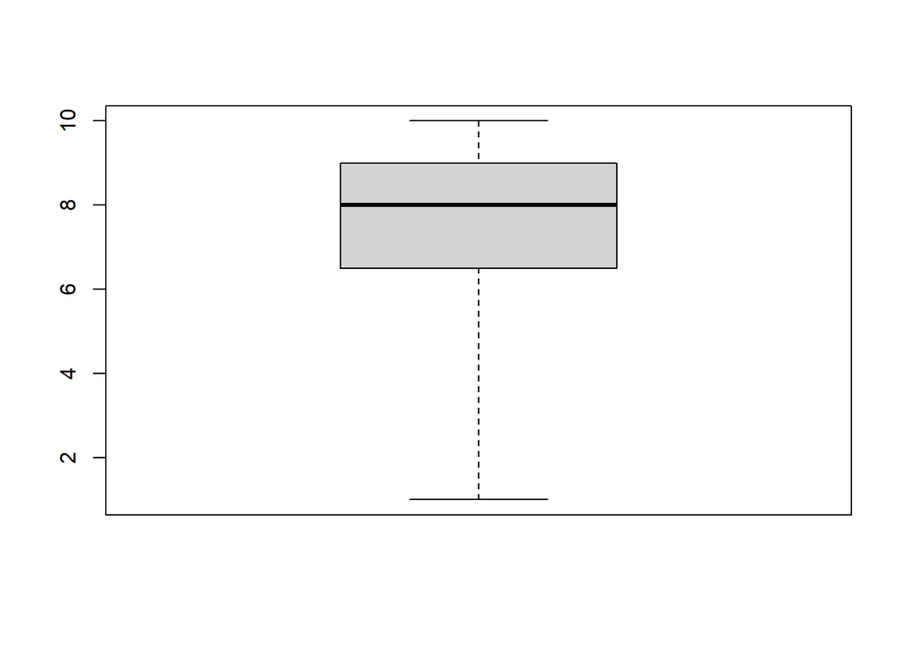

```r
boxplot(Quizzes$Quiz.1, range = 0)
```

Like in **hist()**, we can use the “main”, “xlab”, “ylab”, and “col” arguments to make a prettier graph. We can also add the argument horizontal = TRUE to make this into a horizontal boxplot. If we leave this argument out, it will stay as a vertical boxplot.

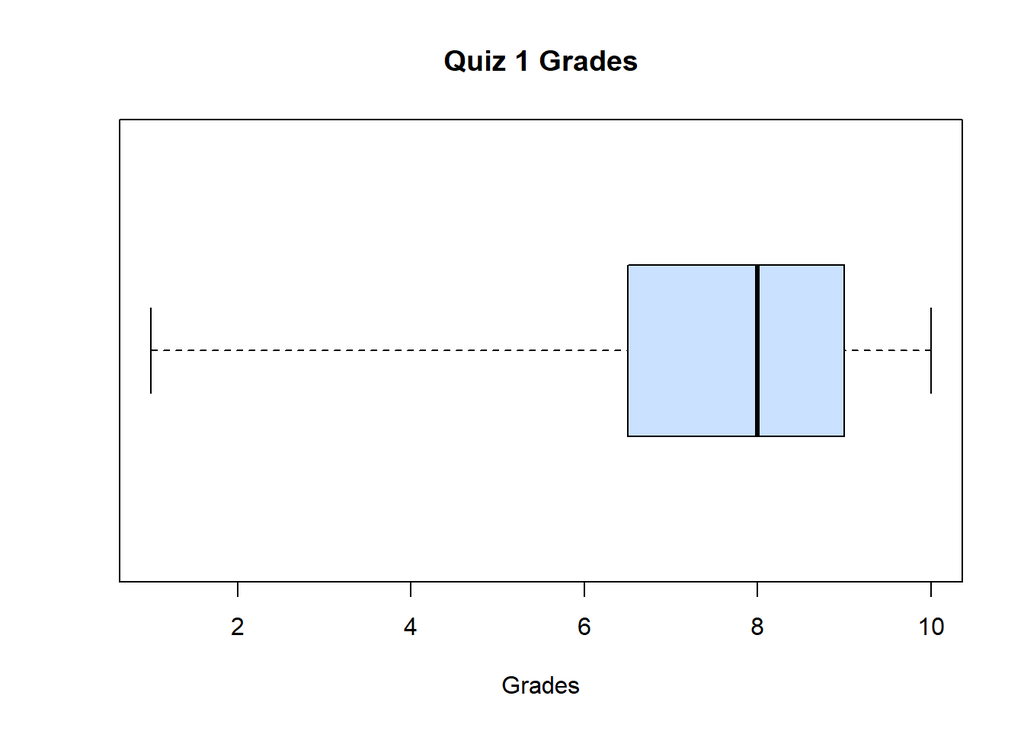

```r
boxplot(Quizzes$Quiz.1, range = 0, horizontal = TRUE, main = "Quiz 1 Grades",
        xlab = "Grades", col = "lightsteelblue1")
```

If we instead want to make a outlier boxplot, we can remove the argument “range = 0”.

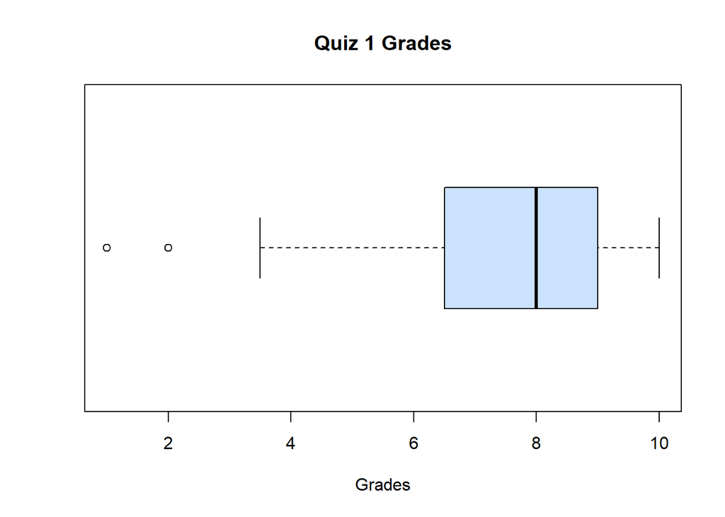

```r
boxplot(Quizzes$Quiz.1, horizontal = TRUE, main = "Quiz 1 Grades",
        xlab = "Grades", col = "lightsteelblue1")
```

The Quizzes dataset consists of the grades of students across four quizzes. In order to compare the grades of the four quizzes, we can make a side-by-side boxplot by specifying all of the boxplots in order.

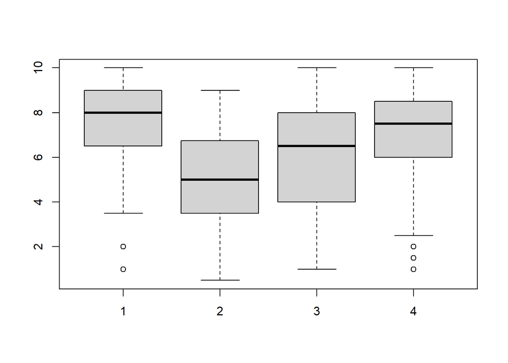

```r
boxplot(Quizzes$Quiz.1, Quizzes$Quiz.2, Quizzes$Quiz.3, Quizzes$Quiz.4)
```

To give each boxplot a name, you can use the **names** argument. Note that you will need to supply a vector of names here.

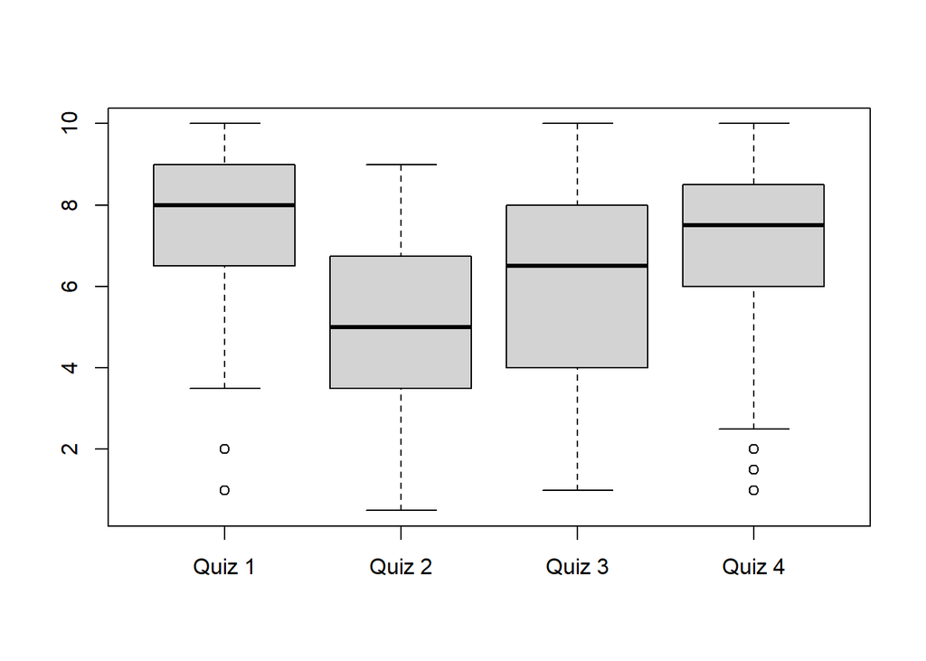

```r
boxplot(Quizzes$Quiz.1, Quizzes$Quiz.2, Quizzes$Quiz.3, Quizzes$Quiz.4,
        names = c("Quiz 1", "Quiz 2", "Quiz 3", "Quiz 4"))
```

We can specify some more arguments to make the side by side boxplot more informative.

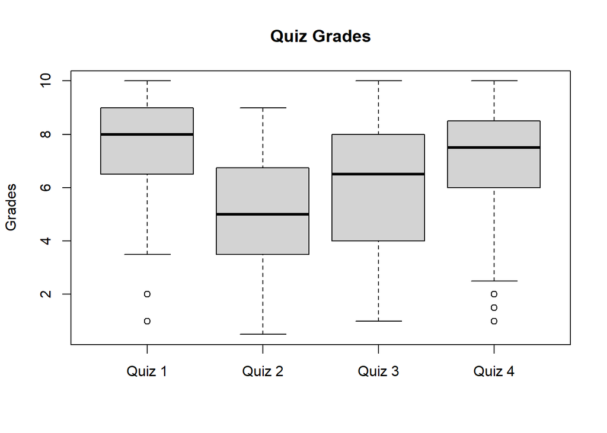

```r
boxplot(Quizzes$Quiz.1, Quizzes$Quiz.2, Quizzes$Quiz.3, Quizzes$Quiz.4,
        names = c("Quiz 1", "Quiz 2", "Quiz 3", "Quiz 4"),
        main = "Quiz Grades", ylab = "Grades")
```

**Note**:

In R, you can create side-by-side boxplots using the tilde sign (~) to specify the formula for plotting multiple variables. Here’s an example:

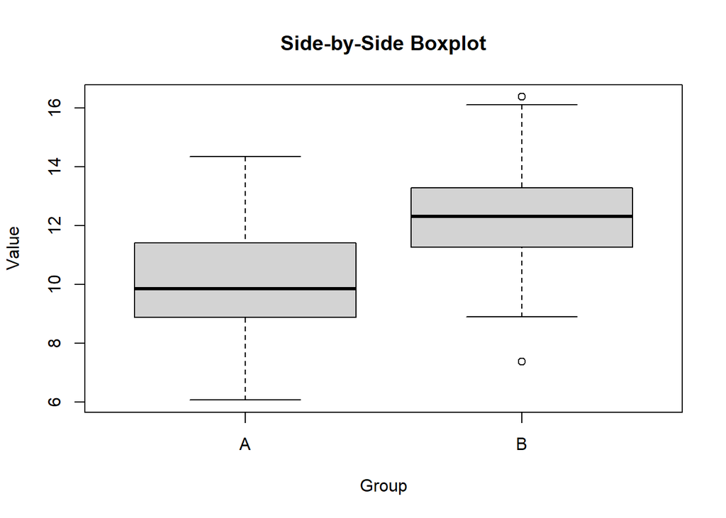

```r
# Sample data
set.seed(123)
data <- data.frame(
  Group = rep(c("A", "B"), each = 50),
  Value = c(rnorm(50, mean = 10, sd = 2), rnorm(50, mean = 12, sd = 2))
)

# Create side-by-side boxplot
boxplot(Value ~ Group, data = data,
        main = "Side-by-Side Boxplot",
        xlab = "Group",
        ylab = "Value")
```

## Additional Functions

In R, there are simply too many functions to provide a full list. However, below we will give a quick reference of some R functions you may want to use in the future.

**sd()**: Function calculates the sample standard deviation of a vector.

```r
sd(Quizzes$Quiz.1)
```

```
## [1] 1.817655
```

**var()**: Function calculates the sample variance of a vector.

```r
var(Quizzes$Quiz.1)
```

```
## [1] 3.30387
```

```r
# sqrt(sd(Quizzes$Quiz.1))
```

**fivenum()**: Function calculates the five-number summary of a vector. Note that R uses a different method of calculating these values than what you have seen in class. So they might see a slight difference between the R output and any by-hand calculations.

```r
fivenum(Quizzes$Quiz.1)
```

```
## [1]  1.0  6.5  8.0  9.0 10.0
```

**IQR()**: Function calculates the interquartile range of a vector.

```r
IQR(Quizzes$Quiz.1)
```

```
## [1] 2.5
```

## Time plots

We can use R to create timeplots. To create a timeplot (specifically, a line graph), we use the function **plot()**.

The **plot()** function in R is a versatile and fundamental tool for creating various types of plots and visualizations. It is used to generate a wide range of plots, including scatter plots, line plots, bar plots, histograms, box plots, and more.

The function plot takes two arguments: the x-axis, and the y-axis.

In order to demonstrate we will import the GDP dataset, which contains Canada’s yearly GDP measurements from 1960 to 2021, in billions of dollars.

```r
GDP <- read.csv("GDP.csv")
```

Let’s create a timeplot of this dataset.

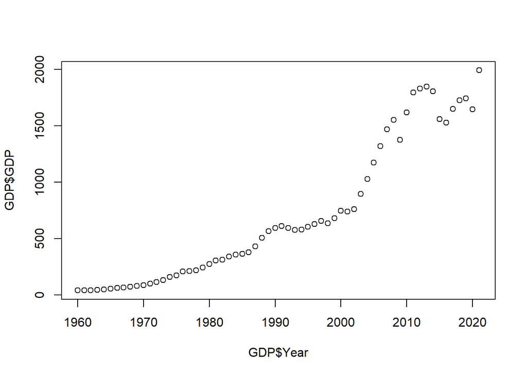

```r
plot(GDP$Year, GDP$GDP)
```

By default, the “plot()” function simply put dots for each data point. To instead use lines, we will specify the argument type = “l”.

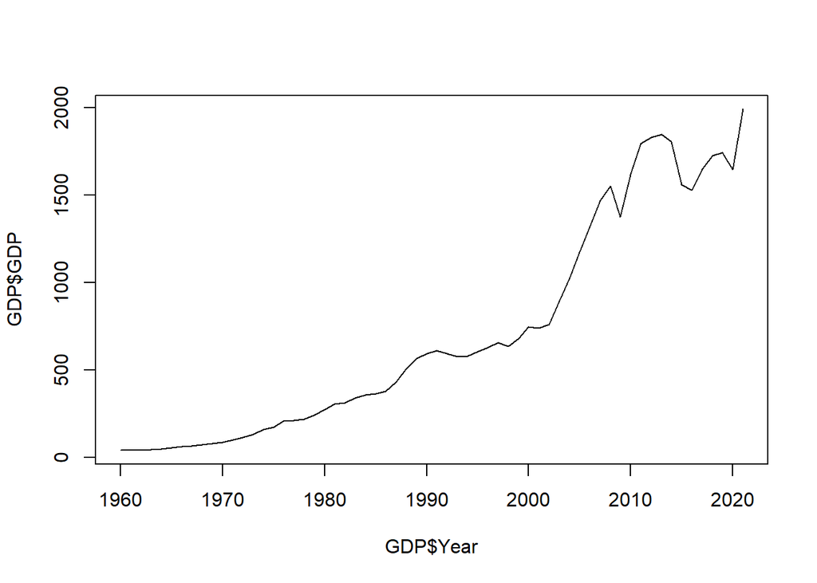

```r
plot(GDP$Year, GDP$GDP, type = "l")
```

We can specify the “lwd” parameter to set the width of the line, and the “lty” parameter to change the type of the line.

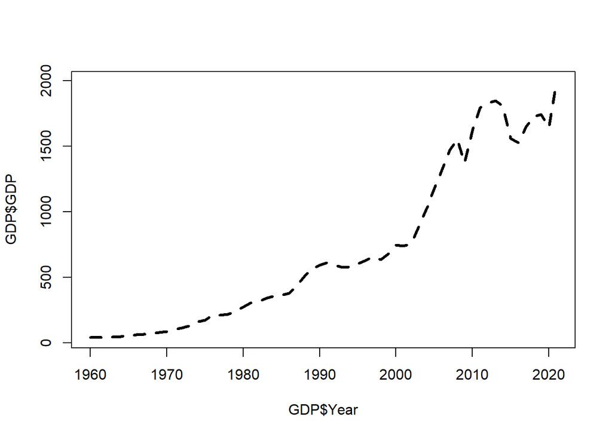

```r
plot(GDP$Year, GDP$GDP, type = "l", lwd = 3, lty = 2)
```

We can use the “main”, “xlab”, “ylab”, and “col” arguments to add more details to this graph.

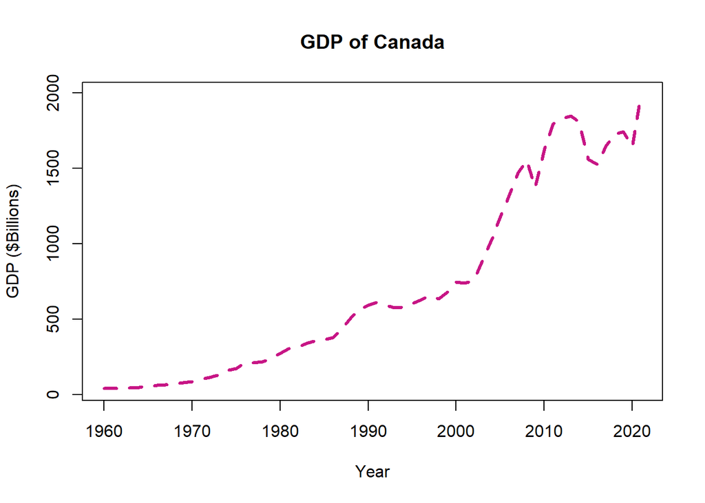

```r
plot(GDP$Year, GDP$GDP, type = "l", lwd = 3, lty = 2,
     main = "GDP of Canada", xlab = "Year", ylab = "GDP ($Billions)",
     col = "mediumvioletred")
```